# BE 5210: Homework 0 Questions

Introduction  
Spring 2024  
15 points  
Due: January 29th 2024  
Objective: Working with the IEEG Portal, basic Python and Colab commands

```python
!jupyter nbconvert --to html YuanchaoZhang_HW0.ipynb
```

```
[NbConvertApp] Converting notebook YuanchaoZhang_HW0.ipynb to html
[NbConvertApp] Writing 2659626 bytes to YuanchaoZhang_HW0.html
```

```python
## Imports and helpful functions

!pip install git+https://github.com/ieeg-portal/ieegpy.git # Install ieegpy toolbox directly from github
from ieeg.auth import Session
from IPython.display import Image
import matplotlib.pyplot as plt
import numpy as np
from scipy import signal as sig

from google.colab import files

def create_pwd_file(username, password, fname=None):
  if fname is None:
    fname = "{}_ieeglogin.bin".format(username[:3])
  with open(fname, 'wb') as f:
    f.write(password.encode())
  files.download(fname)
  print("-- -- IEEG password file saved -- --\n")
```

```
  Cloning https://github.com/ieeg-portal/ieegpy.git to /tmp/pip-req-build-4an4eycy
  Running command git clone --filter=blob:none --quiet https://github.com/ieeg-portal/ieegpy.git /tmp/pip-req-build-4an4eycy
  Resolved https://github.com/ieeg-portal/ieegpy.git to commit 080bfa42a8503380ef164b5e7b116613f75073bb
  Preparing metadata (setup.py) ... done
     ━━━━━━━━━━━━━━━━━━━━━━━━━━━━━━━━━━━━━━━━ 98.0/98.0 kB 2.7 MB/s eta 0:00:00
```

## 1 Unit Activity (15 pts)

The dataset I521 A0001 D001 contains an example of multiunit human iEEG data recorded by Itzhak Fried and colleagues at UCLA using 40 micron platinum-iridium electrodes. Whenever you get new and potentially unfamiliar data, you should always play around with it: plot it, zoom in and out, look at the shape of individual items of interest (here, the spikes). The spikes here will be events appx. 5 ms in duration with amplitudes significantly greater than surrounding background signal.

### 1

Using the time-series visualization functionality of the IEEG Portal find a single time-window containing 3 spikes (use a window width of 500 ms). The signal gain should be adjusted so that the spikes can be seen in entirety. Give a screenshot of the IEEG Portal containing the requested plot. (2 pts)

**My Answer Here:**

[figure not shown]

### 2

Use the provided function `create_pwd_file(username, password)` to generate and download a binary file that encodes your password. This is to make sure that you don't accidentally submit an assignment with your iEEG.org password in it 😎. You will only need to do this once, **but you will need this binary file for every assignment** so save it somewhere where you can access it!

> At the beginning of each new session in Google Colab, you will have to upload the password file. Click on the file icon from the left toolbar, then click the icon labeled *Upload to session storage*. Finally, find your password file in your local file explorer and upload.

Instantiate a new Session in Jupyter Notebook into a reference variable called `session`. Then open the `I521 A0001 D001` dataset into a reference variable called dataset (Hint: refer to the IEEGToolbox manual, class tutorial, or the built-in methods commands in the IEEGSession object - i.e., dir(session)). Print the methods of the session and dataset objects here. (1 pt)

```python
### My code here
username = "Yuanchz1118"
password = "Mgg705201007zyc!"
create_pwd_file(username, password)
```

```
-- -- IEEG password file saved -- --
```

```python
#open the binary file and use its content to create a session frmo IEEG
with open('/content/Yua_ieeglogin.bin', 'r') as f:
  session = Session('Yuanchz1118', f.read())

#get the specified dataset from IEEG
dataset = session.open_dataset('I521_A0001_D001')
```

**My Answer Here:**

```python
print("Methods of the session:", dir(session), "\n")
print("Methods of the dataset:", dir(dataset))
```

```
Methods of the session: ['__class__', '__delattr__', '__dict__', '__dir__', '__doc__', '__enter__', '__eq__', '__exit__', '__format__', '__ge__', '__getattribute__', '__gt__', '__hash__', '__init__', '__init_subclass__', '__le__', '__lt__', '__module__', '__ne__', '__new__', '__reduce__', '__reduce_…

Methods of the dataset: ['_SERVER_GAP_VALUE', '__class__', '__delattr__', '__dict__', '__dir__', '__doc__', '__eq__', '__format__', '__ge__', '__getattribute__', '__gt__', '__hash__', '__init__', '__init_subclass__', '__le__', '__lt__', '__module__', '__ne__', '__new__', '__reduce__', '__reduce_ex__…
```

### 3

How long (in seconds) is this recording? (1 pt)

```python
label = dataset.get_channel_labels()
index = dataset.get_channel_indices(label)
timeseries = dataset.get_time_series_details(label[0])
print(timeseries, "\n")
duration = (timeseries.end_time - timeseries.start_time) / 10**6
print("Duration of this recording:", duration, "seconds")
```

```
None(units) spans 10000000.0 usec, range [-40229-136573] in 320511 samples. Starts @1 uUTC, ends @10000001 uUTC with sample rate 32051.0 Hz and voltage conv factor 0.001

Duration of this recording: 10.0 seconds
```

**My Answer Here:**

10.0 seconds

### 4

What is the sampling rate of the recording? You can find this information by exploring the fields in the timeseries data structure you generated above. Give your answer in Hz. (2 pts)

```python
### My code here
label = dataset.get_channel_labels()
timeseries = dataset.get_time_series_details(label[0])
print(timeseries, "\n")
print("Smpling rate of this recording:",timeseries.sample_rate, "Hz")
```

```
None(units) spans 10000000.0 usec, range [-40229-136573] in 320511 samples. Starts @1 uUTC, ends @10000001 uUTC with sample rate 32051.0 Hz and voltage conv factor 0.001

Smpling rate of this recording: 32051.0 Hz
```

**My answer here:**

The sampling rate of the recording is **32051.0 Hz**.

### 5

#### 5a

Using the session.data.getvalues method retrieve the data from the time-window you plotted in Q1.1 and re-plot this data using matplotlibs plotting functionality. Note that the amplitude of the EEG signals from the portal is measured in units of μV (microvolts), so label your y-axis accordingly. (NOTE: Always make sure to include the correct units and labels in your plots. This goes for the rest of this and all subsequent homeworks.) (3 pts)

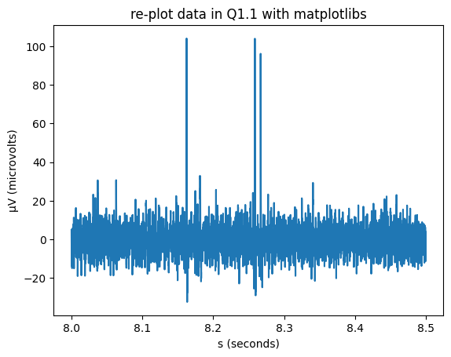

```python
#Your code here
index = dataset.get_channel_indices(label)

### In the plot of Q1.1: Time Range starts at 8s and ends at 8.5s
data = dataset.get_data(8000000, 500000, index)
time_range = np.arange(8, 8.5, 0.5 / len(data))

plt.plot(time_range, data)
plt.xlabel('s (seconds)')
plt.ylabel('μV (microvolts)')
plt.title("re-plot data in Q1.1 with matplotlibs")

plt.show()
```

#### 5b

Write a short bit of code to detect the times of each spike peak (i.e., the time of the maximum spike amplitude) within your time-window. Plot an ’x’ above each spike peak that you detected superimposed on the plot from Q1.5a. (Hint: find where the slope of the signal changes from positive to negative and the signal is also above threshold.) (5 pts)

```
Time of the 1st spike peak: 8.162454761012482 seconds
Time of the 2nd spike peak: 8.258829402220002 seconds
Time of the 3rd spike peak: 8.266910021214093 seconds
```

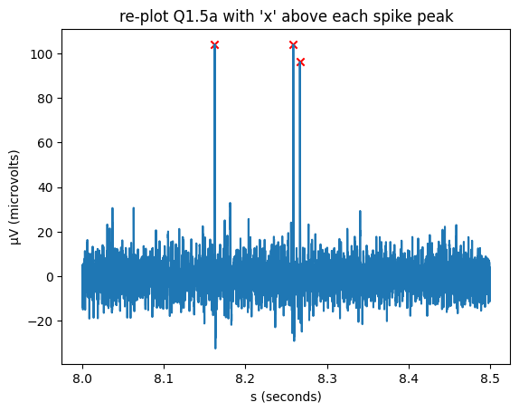

```python
#Your code here
i = 0
time_range_list = []
data_list = []

while (i < len(data)):

  ### Threshold: 40, '+' Slope: Prev < Current ; '-' Slope: Next < Current
  if (data[i][0] > 40 and data[i-1][0] < data[i][0]
  and data[i+1][0] < data[i][0]):

    time_range_list.append(time_range[i])
    data_list.append(data[i][0])

  i = i + 1

### Detect the times of each of three spike peaks
print("Time of the 1st spike peak:", time_range_list[0], "seconds")
print("Time of the 2nd spike peak:", time_range_list[1], "seconds")
print("Time of the 3rd spike peak:", time_range_list[2], "seconds\n\n")

plt.scatter(time_range_list, data_list, marker = 'x', color = 'r')
plt.plot(time_range, data)
plt.xlabel('s (seconds)')
plt.ylabel('μV (microvolts)')
plt.title("re-plot Q1.5a with 'x' above each spike peak")
plt.show()
```

#### 5c

How many spikes do you detect in the entire data sample? (1 pt)

```
List includes times of 32 spike peaks:
 [0.3435150229322018, 2.0192505694050107, 4.212910673613928, 4.238276496833173, 4.891672646719291, 4.901937537050326, 4.9448379145736485, 4.984680665189854, 5.141337243767746, 5.4716233502854825, 5.616611026177031, 5.793204580200306, 5.922685719634333, 5.937193847305856, 6.21228666812268, 6.32248603…
```

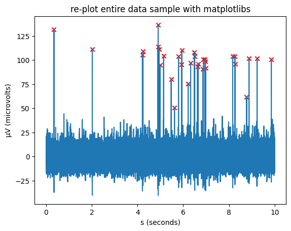

```
32 Spikes
```

```python
#Your code here
### Entire Data Sample: Time Range starts at 0s and ends at 10s
data_new = dataset.get_data(0, 10000000, index)
time_range_new = np.arange(0, 10, 10 / len(data_new))

j = 0
time_range_new_list = []
data_list_new = []

while (j < len(data_new)):

  ### Threshold: 50, '+' Slope: Prev < Current ; '-' Slope: Next < Current
  if (data_new[j][0] > 50 and data_new[j-1][0] < data_new[j][0]
  and data_new[j+1][0] < data_new[j][0]):

    time_range_new_list.append(time_range_new[j])
    data_list_new.append(data_new[j][0])

  j = j + 1

### Detect the times of 32 spike peaks in the entire data sample
print("List includes times of 32 spike peaks:\n", time_range_new_list, "seconds\n\n")

plt.scatter(time_range_new_list, data_list_new, marker = 'x', color = 'r')
plt.plot(time_range_new, data_new)
plt.xlabel('s (seconds)')
plt.ylabel('μV (microvolts)')
plt.title("re-plot entire data sample with matplotlibs")
plt.show()

print(len(data_list_new), "Spikes")
```

**My answer here:**

I detect **32 Spikes** in the entire data sample.